# NYPD_Shooting_Data_Analysis

SathiyaPriya

2023-02-22

## Importing libraries

```r
library(tidyverse)
library(lubridate)
library(dplyr)
```

## Importing the NYPD shooting data (Historic)

```r
url_in <- "https://data.cityofnewyork.us/api/views/833y-fsy8/rows.csv?accessType=DOWNLOAD"
NYPD_shooting_data <- read_csv(url_in)
```

## Tidying and transforming data

1. Converting the ‘occur_date’ column from Character to date datatype.
2. Removing the columns that we do not require for our analysis.

```r
NYPD_shooting_data = mutate(NYPD_shooting_data, OCCUR_DATE = mdy(OCCUR_DATE)) %>%   select(-c(JURISDICTION_CODE,PRECINCT,X_COORD_CD,Y_COORD_CD,Lon_Lat))
```

I found that the ‘perp_age_group’ column had age values that are larger than the typical age of a person. So, I eliminated those larger values.

```r
NYPD_shooting_data= subset(NYPD_shooting_data, PERP_AGE_GROUP!="1020" & PERP_AGE_GROUP!="224" & PERP_AGE_GROUP!="940")
```

Finding the summary of NYPD shooting data

```r
summary(NYPD_shooting_data)
```

```
##   INCIDENT_KEY         OCCUR_DATE          OCCUR_TIME           BORO
##  Min.   :  9953245   Min.   :2006-01-01   Length:16249      Length:16249
##  1st Qu.: 46887795   1st Qu.:2008-06-01   Class1:hms        Class :character
##  Median : 76865005   Median :2011-01-16   Class2:difftime   Mode  :character
##  Mean   : 98432806   Mean   :2012-05-25   Mode  :numeric
##  3rd Qu.:150976933   3rd Qu.:2016-03-06
##  Max.   :238490103   Max.   :2021-12-31
##  LOCATION_DESC      STATISTICAL_MURDER_FLAG PERP_AGE_GROUP
##  Length:16249       Mode :logical           Length:16249
##  Class :character   FALSE:13027             Class :character
##  Mode  :character   TRUE :3222              Mode  :character
##
##
##
##    PERP_SEX          PERP_RACE         VIC_AGE_GROUP        VIC_SEX
##  Length:16249       Length:16249       Length:16249       Length:16249
##  Class :character   Class :character   Class :character   Class :character
##  Mode  :character   Mode  :character   Mode  :character   Mode  :character
##
##
##
##    VIC_RACE            Latitude       Longitude
##  Length:16249       Min.   :40.52   Min.   :-74.23
##  Class :character   1st Qu.:40.67   1st Qu.:-73.94
##  Mode  :character   Median :40.71   Median :-73.91
##                     Mean   :40.74   Mean   :-73.91
##                     3rd Qu.:40.83   3rd Qu.:-73.88
##                     Max.   :40.91   Max.   :-73.71
```

## Analysis of data

#### Analysis 1: Number of Shooting Incidents by BORO and Year

```r
shooting_incident_by_BORO_and_year = NYPD_shooting_data %>%
select(c(INCIDENT_KEY,OCCUR_DATE,BORO)) %>%
mutate(OCCUR_YEAR = format(as.Date(.$OCCUR_DATE),format="%Y")) %>%
group_by(OCCUR_YEAR,BORO) %>%
summarise(n=n())
shooting_incident_by_BORO_and_year
```

```
## # A tibble: 80 × 3
## # Groups:   OCCUR_YEAR [16]
##    OCCUR_YEAR BORO              n
##    <chr>      <chr>         <int>
##  1 2006       BRONX           530
##  2 2006       BROOKLYN        786
##  3 2006       MANHATTAN       251
##  4 2006       QUEENS          273
##  5 2006       STATEN ISLAND    50
##  6 2007       BRONX           473
##  7 2007       BROOKLYN        685
##  8 2007       MANHATTAN       207
##  9 2007       QUEENS          193
## 10 2007       STATEN ISLAND    48
## # … with 70 more rows
```

#### Analysis 2: Number of Shooting Incidents by victim’s race and year

```r
shooting_incident_by_victim_race_and_year = NYPD_shooting_data %>%
select(c(INCIDENT_KEY,OCCUR_DATE,VIC_RACE)) %>%
mutate(OCCUR_YEAR = format(as.Date(.$OCCUR_DATE),format="%Y")) %>%
group_by(OCCUR_YEAR,VIC_RACE) %>%
summarise(n=n())
shooting_incident_by_victim_race_and_year
```

```
## # A tibble: 98 × 3
## # Groups:   OCCUR_YEAR [16]
##    OCCUR_YEAR VIC_RACE                           n
##    <chr>      <chr>                          <int>
##  1 2006       ASIAN / PACIFIC ISLANDER          23
##  2 2006       BLACK                           1298
##  3 2006       BLACK HISPANIC                   101
##  4 2006       UNKNOWN                            2
##  5 2006       WHITE                             42
##  6 2006       WHITE HISPANIC                   424
##  7 2007       AMERICAN INDIAN/ALASKAN NATIVE     1
##  8 2007       ASIAN / PACIFIC ISLANDER          17
##  9 2007       BLACK                           1110
## 10 2007       BLACK HISPANIC                   162
## # … with 88 more rows
```

#### Analysis 3: Number of Shooting Incidents by victim’s age group and year

```r
shooting_incident_by_victim_age_group_and_year = NYPD_shooting_data %>%
select(c(INCIDENT_KEY,OCCUR_DATE,VIC_AGE_GROUP)) %>%
mutate(OCCUR_YEAR = format(as.Date(.$OCCUR_DATE),format="%Y")) %>%
group_by(OCCUR_YEAR,VIC_AGE_GROUP) %>%
summarise(n=n())
shooting_incident_by_victim_age_group_and_year
```

```
## # A tibble: 95 × 3
## # Groups:   OCCUR_YEAR [16]
##    OCCUR_YEAR VIC_AGE_GROUP     n
##    <chr>      <chr>         <int>
##  1 2006       18-24           772
##  2 2006       25-44           750
##  3 2006       45-64           104
##  4 2006       65+              13
##  5 2006       <18             246
##  6 2006       UNKNOWN           5
##  7 2007       18-24           637
##  8 2007       25-44           635
##  9 2007       45-64            93
## 10 2007       65+              10
## # … with 85 more rows
```

#### Analysis 4:To find death rate of shooting incidents by BORO

```r
NYPD_death_rate_by_boro <- NYPD_shooting_data %>%
    group_by(BORO) %>%
    summarize(cases = n(),deaths = sum(STATISTICAL_MURDER_FLAG)) %>%
    mutate(death_rate = round(deaths / cases,3)) %>%
    ungroup()
NYPD_death_rate_by_boro
```

```
## # A tibble: 5 × 4
##   BORO          cases deaths death_rate
##   <chr>         <int>  <int>      <dbl>
## 1 BRONX          4888   1042      0.213
## 2 BROOKLYN       6073   1136      0.187
## 3 MANHATTAN      2235    427      0.191
## 4 QUEENS         2462    489      0.199
## 5 STATEN ISLAND   591    128      0.217
```

## Visualization of data

#### Viz 1: Number of Shooting Incidents by BORO and Year

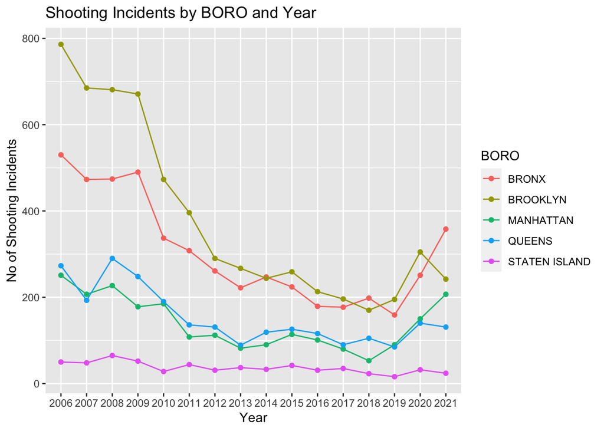

```r
shooting_incident_by_BORO_and_year %>% ggplot(aes(x = OCCUR_YEAR, y = n, group = BORO)) + geom_point(aes(color = BORO)) + geom_line(aes(color = BORO)) +
labs(x = "Year", y = "No of Shooting Incidents", color = "BORO") +
ggtitle("Shooting Incidents by BORO and Year") +
theme(plot.title = element_text(hjust = 0))
```

#### Viz 2: Number of Shooting Incidents by victim’s race and year

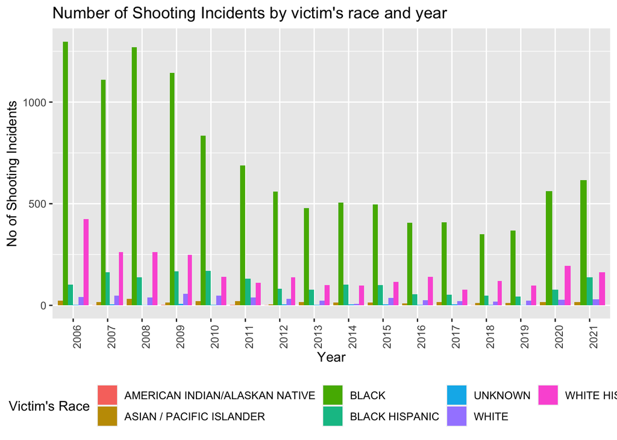

```r
shooting_incident_by_victim_race_and_year %>% ggplot(aes(x = OCCUR_YEAR, y = n, fill = VIC_RACE), color = VIC_RACE) + geom_bar(stat = 'identity', position = 'dodge') +
theme(legend.position = "bottom", axis.text.x = element_text(angle = 90), plot.title = element_text(hjust = 0)) + labs(title = "Number of Shooting Incidents by victim's race and year", y = "No of Shooting Incidents", x = "Year", fill = "Victim's Race")
```

From the above visualization, it is quite evident that the black people are the most affected due to these shooting incidents. The second most affected people are White Hispanics although there is a massive difference between the first two spots.